# SDM with R

# Outline

This tutorial illustrates how to build, evaluate and project species distribution models within R. The main steps we will go through, described bellow, are the following:

# R environment preparation

Download the .zip file from here and extract files to your favorite QCBS R Symposium workshop folder.

Set your working directory to the same directory of the folder `workshopSDM` using the function `setwd()` or your prefered method.

Finally, we recommend to save and create a new working environment for this tutorial.

# Data preparation

## Selecting your study area and manipulating spatial files

Most species distribution models are done using spatial grid information. In the next step, we will learn how to create a polygon grid of a given region, which will be used within our species distribution model framework.

For this tutorial, we have chosen the Neotropical zoogeographical region as our study area. Load the polygon shapefile of it using the `readOGR` function:

```r
neotropical_shape <- rgdal::readOGR("data/shapefiles/neotropical.shp")
```

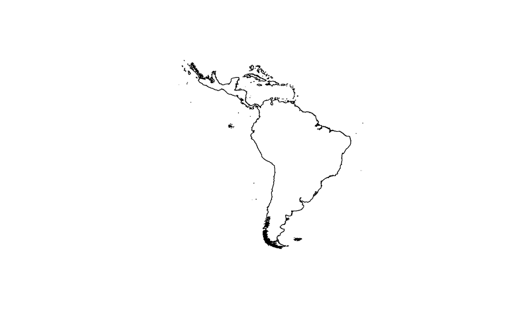

```r
plot(neotropical_shape)
```

Now that we have our study region, we need to create a grid, intersect our shapefile and create a new grid of that region. For this, we will use the modified `GridFilter` function (originally from Hidasi-Neto, J.). It allows us to input a polygon shapefile, specify a resolution and the proportion of overlap for each cell to be considered.

We will apply it, intersect and crop its features with the polygon `neotropical_shape` you have loaded.

This is our resulting polygon grid, where each cell refers to a site (and a row) in our data.

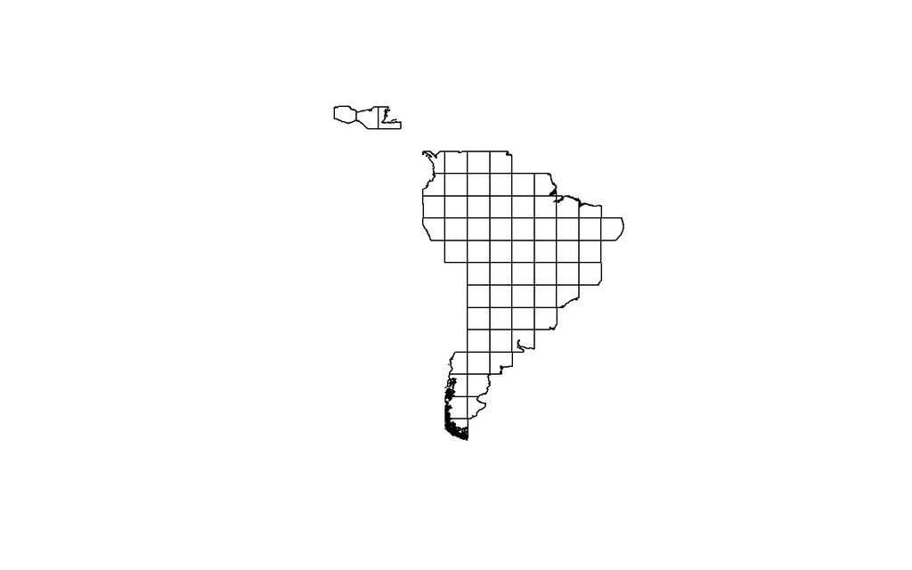

```r
neotropical_grid <- shapefile("data/shapefiles/neotropical_grid_5.shp")

plot(neotropical_grid)
```

We also need the coordinates of our centroids to proceed with the data analysis.

```r
# Extract coordinates from the cell centroids
myRespCoord <- as.data.frame(coordinates(neotropical_grid))
colnames(myRespCoord) <- c("Longitude_X", "Latitude_Y")

# Export it for the future
write.table(myRespCoord, "data/matrices/NT_coords_5.txt")
```

## Importing environmental variables

In species distribution modeling, predictor variables are typically extracted from raster (grid) type files. Each ‘raster’ should represent a given variable of interest, which can be climatic, soil, terrain, vegetation, land use, and other types variables.

The `getData` function from the `dismo` package is able to retrieve useful climate, elevation and administrative data.

You can also load your predictor variables from any directory within your computer using the `raster` (single file) and `stack` (loads multiple files) functions:

```r
rasterFiles <- list.files("data/rasters/bio_10m_bil", pattern = "bil$", full.names = TRUE)
rasterFiles
```

```
 [1] "data/rasters/bio_10m_bil/bio1.bil"
 [2] "data/rasters/bio_10m_bil/bio10.bil"
 [3] "data/rasters/bio_10m_bil/bio11.bil"
 [4] "data/rasters/bio_10m_bil/bio12.bil"
 [5] "data/rasters/bio_10m_bil/bio13.bil"
 [6] "data/rasters/bio_10m_bil/bio14.bil"
 [7] "data/rasters/bio_10m_bil/bio15.bil"
 [8] "data/rasters/bio_10m_bil/bio16.bil"
 [9] "data/rasters/bio_10m_bil/bio17.bil"
[10] "data/rasters/bio_10m_bil/bio18.bil"
[11] "data/rasters/bio_10m_bil/bio19.bil"
[12] "data/rasters/bio_10m_bil/bio2.bil"
[13] "data/rasters/bio_10m_bil/bio3.bil"
[14] "data/rasters/bio_10m_bil/bio4.bil"
[15] "data/rasters/bio_10m_bil/bio5.bil"
[16] "data/rasters/bio_10m_bil/bio6.bil"
[17] "data/rasters/bio_10m_bil/bio7.bil"
[18] "data/rasters/bio_10m_bil/bio8.bil"
[19] "data/rasters/bio_10m_bil/bio9.bil"
```

```r
bioClimVars <- stack(rasterFiles)
bioClimVars
```

```
class       : RasterStack
dimensions  : 900, 2160, 1944000, 19  (nrow, ncol, ncell, nlayers)
resolution  : 0.1666667, 0.1666667  (x, y)
extent      : -180, 180, -60, 90  (xmin, xmax, ymin, ymax)
coord. ref. : +proj=longlat +ellps=WGS84 +towgs84=0,0,0,0,0,0,0 +no_defs
names       :  bio1, bio10, bio11, bio12, bio13, bio14, bio15, bio16, bio17, bio18, bio19,  bio2,  bio3,  bio4,  bio5, ...
min values  :  -269,   -97,  -488,     0,     0,     0,     0,     0,     0,     0,     0,     9,     8,    72,   -59, ...
max values  :   314,   380,   289,  9916,  2088,   652,   261,  5043,  2159,  4001,  3985,   211,    95, 22673,   489, ...
```

You can also plot your variables to take a look at them:

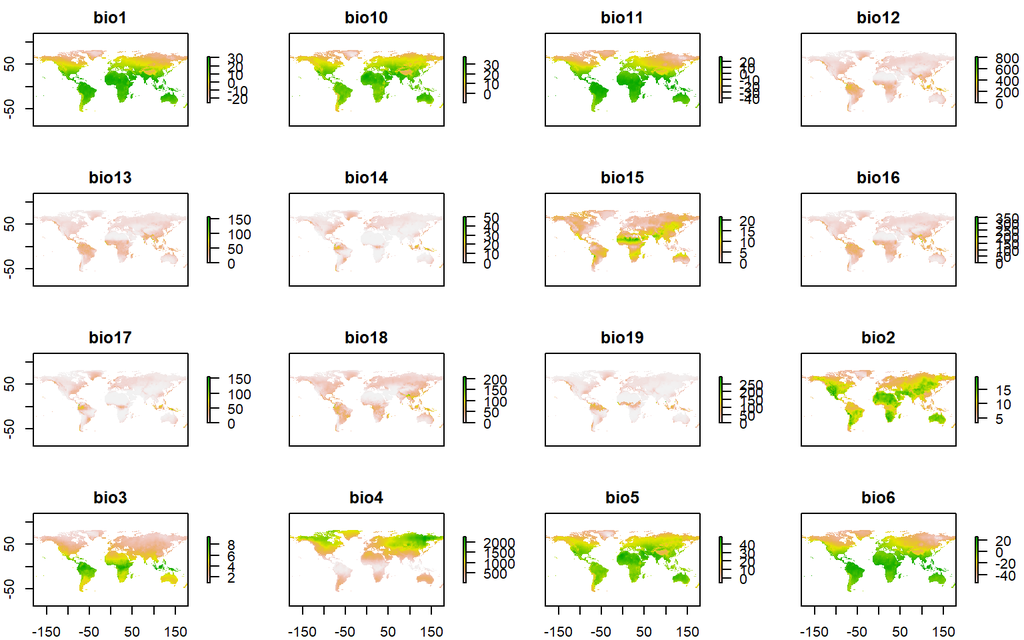

```r
plot(bioClimVars/10)  # WorldClim data is multiplied by 10. Let's take a look at the real information.
```

### Variable extraction

Before extracting variables, it is really important that your rasters have the same projection (i.e. type of coordinate reference system) as your other spatial files. See `?CRS` for help in finding CRS definitions.

```r
crs.geo <- CRS("+proj=longlat +ellps=WGS84 +datum=WGS84")  # geographical, datum WGS84

proj4string(neotropical_grid) <- crs.geo  # define projection system of grid data
proj4string(bioClimVars) <- crs.geo  # and of our bioclimatic rasters
```

Now, we can extract the predictor values for each cell of our grid!

```r
myExpl <- data.frame(bio_1 = numeric(length(neotropical_grid)), bio_2 = numeric(length(neotropical_grid)),
    bio_3 = numeric(length(neotropical_grid)))

bio_1_ext <- extract(bioClimVars$bio1, neotropical_grid)  # bio_1_ext is a list of cells that contains all values for each cell, for each predictor
bio_2_ext <- extract(bioClimVars$bio2, neotropical_grid)
bio_3_ext <- extract(bioClimVars$bio3, neotropical_grid)

myExpl$bio_1 <- unlist(lapply(bio_1_ext, function(x) if (!is.null(x)) mean(x,
    na.rm = TRUE) else NA))

myExpl$bio_2 <- unlist(lapply(bio_2_ext, function(x) if (!is.null(x)) mean(x,
    na.rm = TRUE) else NA))

myExpl$bio_3 <- unlist(lapply(bio_1_ext, function(x) if (!is.null(x)) mean(x,
    na.rm = TRUE) else NA))

# Let's take a look at our table:
head(myExpl)
```

```
     bio_1     bio_2    bio_3
1 215.9267 138.49084 215.9267
2 236.4301 114.60676 236.4301
3 241.8685  99.48434 241.8685
4 239.1822  91.49031 239.1822
5 235.9922  99.52013 235.9922
6 269.0044 101.91778 269.0044
```

Save your results and proceed to the next step.

## Importing species data

### Using expert drawn maps

One way of acquiring species distribution information is from expert-drawn maps, such as the ones from the IUCN Red List for Threatened Species database. These maps Tare usually done used multiple methods: only on occurrence data (e.g. a polygon around known occurrences), whereas others incorporate multiple degrees of knowledge, such as habitat requirements or elevational limits of the species, in essence using an informal distribution modelling approach.

Richness maps derived from expert-drawn range maps may overestimate local richness (‘error of commission’), in relation to point-to-grid richness maps. This because they are generally drawn to include all areas where a species is known to occur without excluding areas in between where the species may not exist. They tend to map the ‘extent of occurrence’ of species that includes the, perhaps much smaller, ‘area of occupancy’ (Loiselle et al., 2003; Habib et al., 2004; Hurlbert & White, 2005; Graham & Hijmans, 2006). We advise caution when using them.

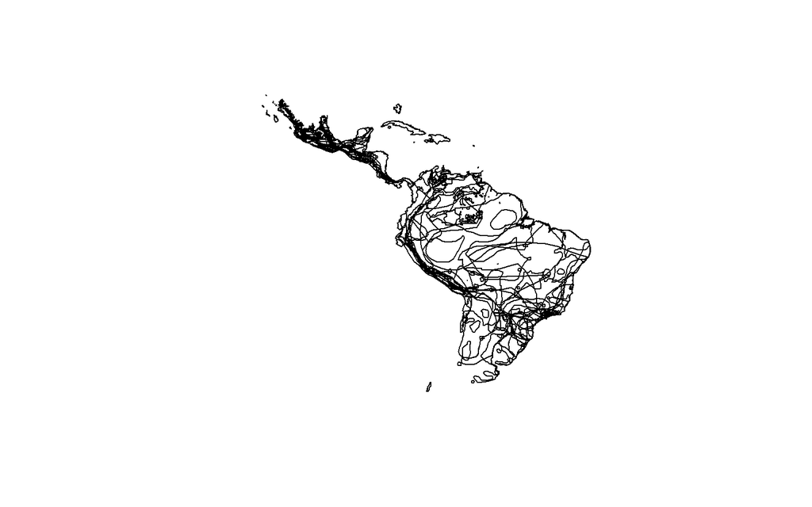

```r
speciesGeoDist <- readShapePoly("data/shapefiles/NT_TERRESTRIAL_MAMMALS_subset.shp",
    proj4string = crs.geo)
plot(speciesGeoDist)
```

Create a presence-absence matrix of species’ geographic ranges within your polygon grid shapefile. For this, we will use the function `lets.presab.grid` from the `letsR` package.

```r
abspres.matrix <- lets.presab.grid(shapes = speciesGeoDist, grid = neotropical_grid,
    sample.unit = "ID", remove.sp = TRUE, presence = NULL, origin = NULL, seasonal = NULL)
```

You can now visualize a map of your species richness within your polygon grid:

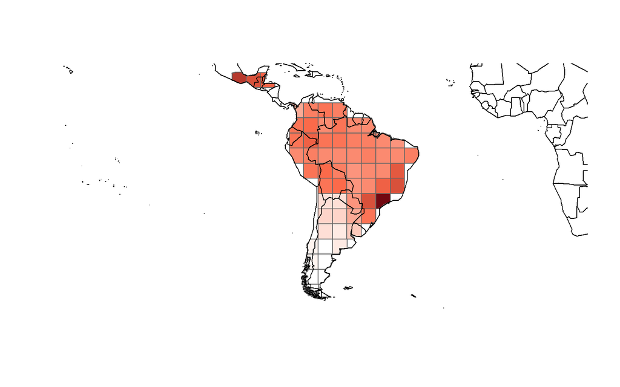

```r
richnessCalc <- rowSums(abspres.matrix$PAM) + 1
colPalette <- colorRampPalette(c("#fff5f0", "#fb6a4a", "#67000d"))
colors <- c("white", colPalette(max(richnessCalc)))
plot(abspres.matrix$grid, border = "gray40", col = colors[richnessCalc])
map(add = TRUE)
```

### Using occurrence records

We can also use occurrence records available online, or collected in the field. Here, we will use information from the Global Biodiversity Information Facility and import it using the function `gbif`:

```r
D_youngi.GBIF <- gbif("Diaemus", "youngi")
```

```r
# get data frame with spatial coordinates (points)
Dyoungi.Occ <- subset(D_youngi.GBIF, select = c("country", "lat", "lon"))
head(Dyoungi.Occ)  # a simple data frame with coordinates
```

```
              country      lat       lon
1           Nicaragua 11.11199 -85.76016
2 Trinidad and Tobago 10.54603 -61.48618
3            Suriname  1.99449 -56.09211
4            Suriname  1.99000 -56.09000
5            Suriname  1.99400 -56.09200
6            Suriname       NA        NA
```

## Data cleaning

Let’s take a look at our species matrix. What is going when we look at the sum of the columns (i.e. number of presences)?

```r
# Load our species data
DataSpecies <- read.table("data/matrices/NT_PAM_5.txt", header = TRUE)

colSums(DataSpecies)
```

```
            Panthera.onca             Pecari.tajacu
                       50                        55
      Peromyscus.leucopus   Phyllostomus.latifolius
                        3                        10
        Philander.opossum     Phyllomys.nigrispinus
                       39                         3
     Peromyscus.mexicanus       Phyllomys.dasythrix
                        3                         2
   Oxymycterus.amazonicus      Oxymycterus.hispidus
                        8                         5
      Peropteryx.macrotis      Pattonomys.carrikeri
                       47                         1
        Oxymycterus.josei   Peropteryx.pallidoptera
                        1                         5
        Oxymycterus.hiska        Peromyscus.aztecus
                        3                         3
        Peromyscus.beatae          Philander.deltae
                        3                         1
      Phylloderma.stenops         Peromyscus.furvus
                       43                         1
        Oxymycterus.rufus        Peromyscus.grandis
                        7                         2
    Phaenomys.ferrugineus       Peropteryx.kappleri
                        1                        44
    Phyllomys.blainvillii    Phyllomys.brasiliensis
                        3                         2
       Peromyscus.levipes       Philander.mondolfii
                        1                         5
       Philander.frenatus Phyllomys.mantiqueirensis
                        7                         1
   Phyllostomus.elongatus       Oxymycterus.nasutus
                       41                         5
     Peromyscus.hylocetes       Oxymycterus.hucucha
                        1                         2
      Oxymycterus.roberti   Oxymycterus.dasytrichus
                        7                         3
    Oxymycterus.angularis          Phyllomys.medius
                        3                         3
      Peromyscus.megalops       Pattonomys.occasius
                        2                         3
```

[output cut: 13 more lines]

```
                        1                         1
       Perognathus.flavus    Oxymycterus.paramensis
                        1                         7
         Oxymycterus.inca     Phyllostomus.discolor
                        5                        46
    Peromyscus.difficilis      Peromyscus.melanotis
                        1                         1
        Phyllomys.lamarum   Pattonomys.semivillosus
                        3                         1
          Phyllomys.lundi       Peromyscus.stirtoni
                        1                         2
        Phyllomys.pattoni         Phyllomys.sulinus
                        4                         3
   Peromyscus.melanophrys      Oxymycterus.caparoae
                        2                         2
```

We can work on that by removing species that occur in less than four sites.

# Species distribution modelling

## Initialising and formatting direct input data

First, input data needs to be rearranged for usage in biomod2 using `BIOMOD_FormatingData()`. Its most important arguments are: * `resp.var` contains **species data** (for a single species) in **binary format** (ones for presences, zeros for true absences and NA for indeterminated) that will be used **to build the species distribution models**. It may be a vector or a spatial points object. * `expl.var` contains a matrix, data.frame, SpatialPointsDataFrame or RasterStack containing your explanatory variables. * `resp.xy` two columns matrix containing the X and Y coordinates of resp.var (only consider if resp.var is a vector) * `resp.name` contains the response variable name (species).

```r
# Recall your variables again:

## Load prepared species data
myResp <-  read.table("data/matrices/NT_PAM_5.txt", header=TRUE)

## Load environmental variables
myExpl <-  read.table("data/matrices/NT_EnvVar_5.txt", header=TRUE)

# Define the species of interest
myRespName <- names(DataSpecies)[1]

# Load coordinates
myRespCoord <- read.table("data/matrices/NT_coords_5.txt", header=TRUE)

myBiomodData <- BIOMOD_FormatingData(resp.var = as.numeric(DataSpecies[,myRespName]),
                                     expl.var = myExpl,
                                     resp.xy = myRespCoord,
                                     resp.name = myRespName,
                                     #PA.nb.rep = 2,
                                     #PA.nb.absences = 200,
                                     #PA.strategy = 'random',
                                     na.rm = TRUE)
```

```
-=-=-=-=-=-=-=-=-=-=-= Panthera.onca Data Formating -=-=-=-=-=-=-=-=-=-=-=

> No pseudo absences selection !
      ! No data has been set aside for modeling evaluation
-=-=-=-=-=-=-=-=-=-=-=-=-=-=-=-=-= Done -=-=-=-=-=-=-=-=-=-=-=-=-=-=-=-=-=
```

Now, you may check if your data is correctly formatted by printing and ploting the `myBiomodData` object.

```r
myBiomodData
```

```
-=-=-=-=-=-=-=-=-=-=-=-=-= 'BIOMOD.formated.data' -=-=-=-=-=-=-=-=-=-=-=-=-=

sp.name =  Panthera.onca

     50 presences,  13 true absences and  0 undifined points in dataset


     2 explanatory variables

     bio_1            bio_2
 Min.   : 54.06   Min.   : 80.49
 1st Qu.:182.15   1st Qu.: 99.89
 Median :236.43   Median :117.75
 Mean   :211.69   Mean   :115.79
 3rd Qu.:256.98   3rd Qu.:128.26
 Max.   :269.00   Max.   :162.52

-=-=-=-=-=-=-=-=-=-=-=-=-=-=-=-=-=-=-=-=-=-=-=-=-=-=-=-=-=-=-=-=-=-=-=-=-=-=
```

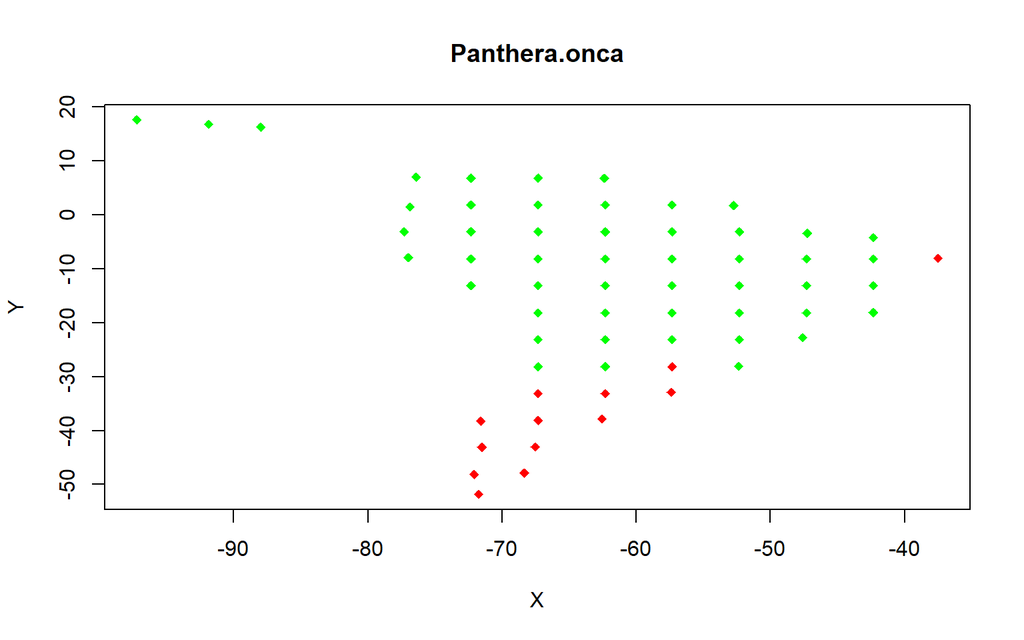

```r
plot(myBiomodData)
```

## Building models

### Defining algorithm parameters using default options

We are ready for running our set of models on our species. This step is the core of the modeling procedure.

First, we define the of different options for each modeling technique using the function `BIOMOD_ModelingOptions()`. If we do not change its parameters, it will take the default values (run `Print_Default_ModelingOptions()` to see them) defined within `biomod2`. For the sake of simplicity, we will keep all options default.

```r
myBiomodOption <- BIOMOD_ModelingOptions()

# The created object is then given to BIOMOD_Modeling in the next step.
```

### Computing models

As we do not have evaluation data, we will make 3-fold cross-validation (number controlled by `NbRunEval` argument) of our models by randomly splitting our data set into 2 subsets `DataSplit`.

Take a look below:

[output not shown]

## Model evaluation

### Extracting evaluation scores

We are able now to capture our model evaluations using the `get_evaluations` function. In this tutorial, we have focused on two evaluations methods: Receiving Operator Curves and True Skill Statistic.

```r
# get all models evaluation
myBiomodModelEval <- get_evaluations(myBiomodModelOut)  #contains model evaluation scores

# print the dimnames of this object
dimnames(myBiomodModelEval)
```

```
[[1]]
[1] "TSS" "ROC"

[[2]]
[1] "Testing.data" "Cutoff"       "Sensitivity"  "Specificity"

[[3]]
[1] "GBM"             "GLM"             "MAXENT.Tsuruoka" "RF"

[[4]]
[1] "RUN1" "RUN2" "RUN3"

[[5]]
Panthera.onca_AllData
            "AllData"
```

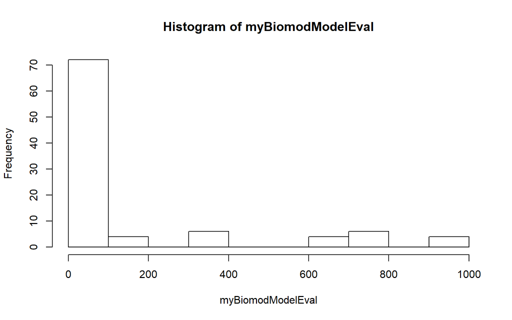

```r
hist(myBiomodModelEval)
```

```r
write.table(myBiomodModelEval, file = "data/results/EvalAll_Model_Eval")
```

### Plotting evaluation scores

We can also plot evaluation scores for sensitivity and specifity for all models.

```r
# print the Sensitivity of all models --> TSS and ROC scores for SENSITIVITY
mySensitivity_All_Models <- myBiomodModelEval[, "Sensitivity", , , ]
mySensitivity_All_Models
```

```
, , RUN1

    GBM GLM MAXENT.Tsuruoka RF
TSS  80  40              90 70
ROC  80  40              90 70

, , RUN2

    GBM GLM MAXENT.Tsuruoka RF
TSS  80  50              60 70
ROC  80  50              60 70

, , RUN3

    GBM GLM MAXENT.Tsuruoka  RF
TSS 100 100              90 100
ROC 100 100              90 100
```

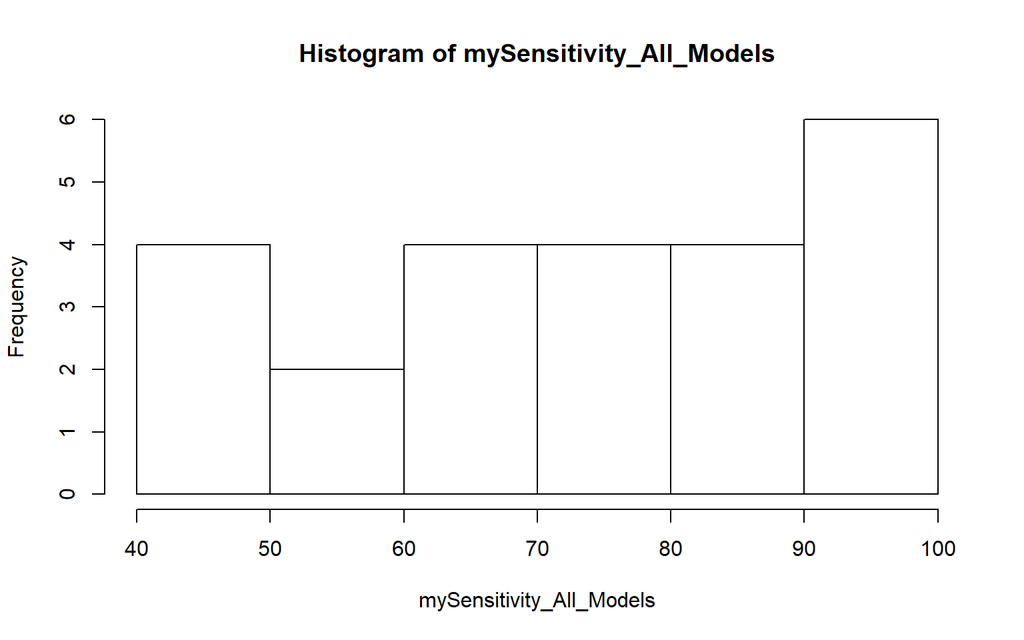

```r
hist(mySensitivity_All_Models)
```

```r
# save results
write.table(mySensitivity_All_Models, file = "data/results/Sensitivity_All_Models")
```

[output not shown]

[figure not shown]

```r
# Proportion of PRESENCES correctly predicted (true positive rate)
sensitivity <- read.table("data/results/Sensitivity_All_Models")

summary(sensitivity)
```

```
    GBM.RUN1     GLM.RUN1  MAXENT.Tsuruoka.RUN1    RF.RUN1      GBM.RUN2
 Min.   :80   Min.   :40   Min.   :90           Min.   :70   Min.   :80
 1st Qu.:80   1st Qu.:40   1st Qu.:90           1st Qu.:70   1st Qu.:80
 Median :80   Median :40   Median :90           Median :70   Median :80
 Mean   :80   Mean   :40   Mean   :90           Mean   :70   Mean   :80
 3rd Qu.:80   3rd Qu.:40   3rd Qu.:90           3rd Qu.:70   3rd Qu.:80
 Max.   :80   Max.   :40   Max.   :90           Max.   :70   Max.   :80
    GLM.RUN2  MAXENT.Tsuruoka.RUN2    RF.RUN2      GBM.RUN3
 Min.   :50   Min.   :60           Min.   :70   Min.   :100
 1st Qu.:50   1st Qu.:60           1st Qu.:70   1st Qu.:100
 Median :50   Median :60           Median :70   Median :100
 Mean   :50   Mean   :60           Mean   :70   Mean   :100
 3rd Qu.:50   3rd Qu.:60           3rd Qu.:70   3rd Qu.:100
 Max.   :50   Max.   :60           Max.   :70   Max.   :100
    GLM.RUN3   MAXENT.Tsuruoka.RUN3    RF.RUN3
 Min.   :100   Min.   :90           Min.   :100
 1st Qu.:100   1st Qu.:90           1st Qu.:100
 Median :100   Median :90           Median :100
 Mean   :100   Mean   :90           Mean   :100
 3rd Qu.:100   3rd Qu.:90           3rd Qu.:100
 Max.   :100   Max.   :90           Max.   :100
```

```r
str(sensitivity)
```

```
'data.frame':   2 obs. of  12 variables:
 $ GBM.RUN1            : int  80 80
 $ GLM.RUN1            : int  40 40
 $ MAXENT.Tsuruoka.RUN1: int  90 90
 $ RF.RUN1             : int  70 70
 $ GBM.RUN2            : int  80 80
 $ GLM.RUN2            : int  50 50
 $ MAXENT.Tsuruoka.RUN2: int  60 60
 $ RF.RUN2             : int  70 70
 $ GBM.RUN3            : int  100 100
 $ GLM.RUN3            : int  100 100
 $ MAXENT.Tsuruoka.RUN3: int  90 90
 $ RF.RUN3             : int  100 100
```

```r
sensitivity  #table of sensitivity by TSS or ROC per run per model
```

```
    GBM.RUN1 GLM.RUN1 MAXENT.Tsuruoka.RUN1 RF.RUN1 GBM.RUN2 GLM.RUN2
TSS       80       40                   90      70       80       50
ROC       80       40                   90      70       80       50
    MAXENT.Tsuruoka.RUN2 RF.RUN2 GBM.RUN3 GLM.RUN3 MAXENT.Tsuruoka.RUN3
TSS                   60      70      100      100                   90
ROC                   60      70      100      100                   90
    RF.RUN3
TSS     100
ROC     100
```

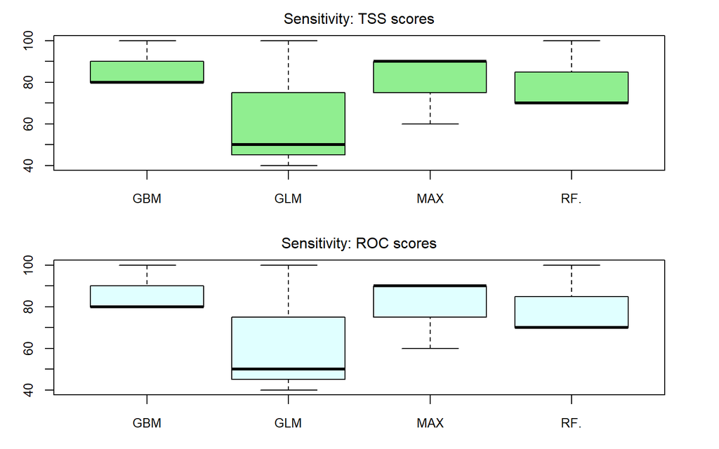

```r
# pdf('data/results/Sensitivity scores.pdf') # can save these plots as pdf
par(mfrow = c(2, 1), mar = c(3, 3, 2, 3), font.main = c(1), ps = c(10))

boxplot(TSS ~ model1, data = sensPlot1, main = "Sensitivity: TSS scores", ylab = "TSS score",
    drop.unused.levels = TRUE, notch = F, show.names = T, col = "light green")

boxplot(ROC ~ model2, data = sensPlot2, main = "Sensitivity: ROC scores", ylab = "ROC score",
    drop.unused.levels = TRUE, notch = F, show.names = T, col = "light cyan")
```

```r
# dev.off()
```

Discussion: How do the models compare by their sensitivity scores?

```r
##### plot SPECIFICITY #####

# Proportion of ABSENCES correctly predicted (true negative rate)

specificity <- read.table("data/results/Specificity_All_Models")
summary(specificity)
```

```
    GBM.RUN1      GLM.RUN1   MAXENT.Tsuruoka.RUN1    RF.RUN1
 Min.   :100   Min.   :100   Min.   :100          Min.   :100
 1st Qu.:100   1st Qu.:100   1st Qu.:100          1st Qu.:100
 Median :100   Median :100   Median :100          Median :100
 Mean   :100   Mean   :100   Mean   :100          Mean   :100
 3rd Qu.:100   3rd Qu.:100   3rd Qu.:100          3rd Qu.:100
 Max.   :100   Max.   :100   Max.   :100          Max.   :100
    GBM.RUN2        GLM.RUN2   MAXENT.Tsuruoka.RUN2    RF.RUN2
 Min.   :66.67   Min.   :100   Min.   :100          Min.   :66.67
 1st Qu.:66.67   1st Qu.:100   1st Qu.:100          1st Qu.:66.67
 Median :66.67   Median :100   Median :100          Median :66.67
 Mean   :66.67   Mean   :100   Mean   :100          Mean   :66.67
 3rd Qu.:66.67   3rd Qu.:100   3rd Qu.:100          3rd Qu.:66.67
 Max.   :66.67   Max.   :100   Max.   :100          Max.   :66.67
    GBM.RUN3        GLM.RUN3     MAXENT.Tsuruoka.RUN3    RF.RUN3
 Min.   :66.67   Min.   :66.67   Min.   :66.67        Min.   :66.67
 1st Qu.:66.67   1st Qu.:66.67   1st Qu.:66.67        1st Qu.:66.67
 Median :66.67   Median :66.67   Median :66.67        Median :66.67
 Mean   :66.67   Mean   :66.67   Mean   :66.67        Mean   :66.67
 3rd Qu.:66.67   3rd Qu.:66.67   3rd Qu.:66.67        3rd Qu.:66.67
 Max.   :66.67   Max.   :66.67   Max.   :66.67        Max.   :66.67
```

```r
str(specificity)
```

```
'data.frame':   2 obs. of  12 variables:
 $ GBM.RUN1            : int  100 100
 $ GLM.RUN1            : int  100 100
 $ MAXENT.Tsuruoka.RUN1: int  100 100
 $ RF.RUN1             : int  100 100
 $ GBM.RUN2            : num  66.7 66.7
 $ GLM.RUN2            : int  100 100
 $ MAXENT.Tsuruoka.RUN2: int  100 100
 $ RF.RUN2             : num  66.7 66.7
 $ GBM.RUN3            : num  66.7 66.7
 $ GLM.RUN3            : num  66.7 66.7
 $ MAXENT.Tsuruoka.RUN3: num  66.7 66.7
 $ RF.RUN3             : num  66.7 66.7
```

```r
specificity  #table of specificity by TSS or ROC per run per model
```

```
    GBM.RUN1 GLM.RUN1 MAXENT.Tsuruoka.RUN1 RF.RUN1 GBM.RUN2 GLM.RUN2
TSS      100      100                  100     100   66.667      100
ROC      100      100                  100     100   66.667      100
    MAXENT.Tsuruoka.RUN2 RF.RUN2 GBM.RUN3 GLM.RUN3 MAXENT.Tsuruoka.RUN3
TSS                  100  66.667   66.667   66.667               66.667
ROC                  100  66.667   66.667   66.667               66.667
    RF.RUN3
TSS  66.667
ROC  66.667
```

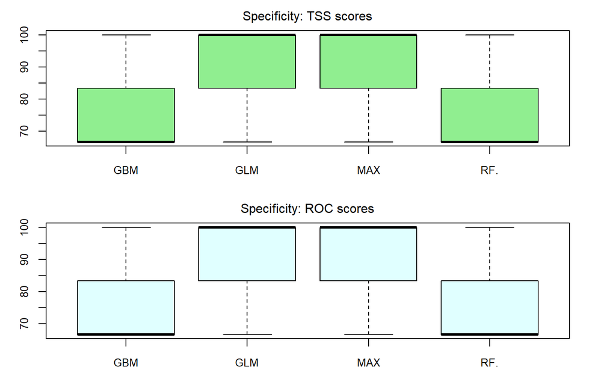

```r
specTSS <- specificity[1, ]
specTran <- t(specTSS)
modelNames <- rownames(specTran)
model1 <- substr(modelNames, 1, 3)
specPlot1 <- data.frame(specTran, model1)

specROC <- specificity[2, ]
specTran <- t(specROC)
modelNames <- rownames(specTran)
model2 <- substr(modelNames, 1, 3)
specPlot2 <- data.frame(specTran, model2)

# pdf('Specificity scores.pdf')
par(mfrow = c(2, 1), mar = c(3, 3, 2, 3), font.main = c(1), ps = c(10))
boxplot(TSS ~ model1, data = specPlot1, main = "Specificity: TSS scores", ylab = "TSS score",
    drop.unused.levels = TRUE, notch = F, show.names = T, col = "light green")

boxplot(ROC ~ model2, data = specPlot2, main = "Specificity: ROC scores", ylab = "ROC score",
    drop.unused.levels = TRUE, notch = F, show.names = T, col = "light cyan")
```

```r
# dev.off()
```

## Ensemble of forecasting

# Multi-species modelling

Now, that we know how to do single species modelling, what changes if we want to model the distribution of *n* species?

Pedro Henrique Braga and Julia Nordlund

April 23, 2017